# Лабораторная работа № 12

Операционные системы

Иванов Сергей Владимирович, НПИбд-01-23

Российский университет дружбы народов, Москва, Россия

23 апреля 2024

## Цель работы

Цель данной лабораторной работы - изучить основы программирования в оболочке ОС UNIX/Linux, научиться писать небольшие командные файлы.

# Выполнение работы

## Выполнение программы 1

Создаю файл prog1.sh, делаю его исполняемым, пишу в нем код, и запускаю его

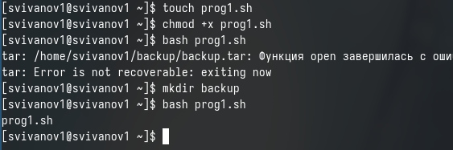

Выполнение программы 1

## Написанная программа 1

Скрипт, который при запуске будет делать резервную копию самого себя

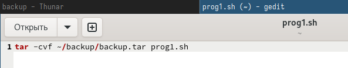

Написанная программа 1

## Выполнение программы 2

Создаю файл prog2.sh, делаю его исполняемым, пишу в нем код, и запускаю его

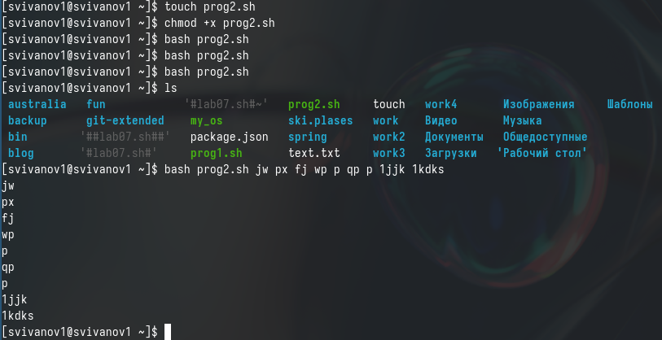

Выполнение программы 2

## Написання программа 2

Пример командного файла, обрабатывающего произвольное число аргументов, в том числе превышающее десять.

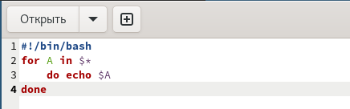

Написання программа 2

## Выполнение программы 3

Создаю файл prog3.sh, делаю его исполняемым, пишу в нем код, и запускаю его

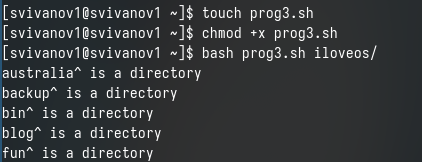

Выполнение программы 3

## Написанная программа программа 3

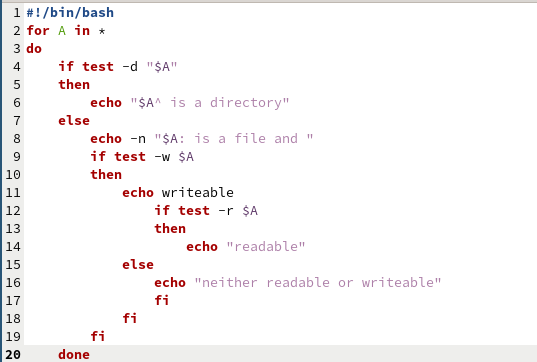

Написанная программа программа 3

## Создание файла с программой 4

Создаю файл prog4.sh, делаю его исполняемым, пишу в нем код

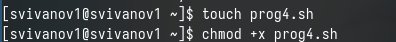

Создание файла с программой 4

## Написанная программа 4

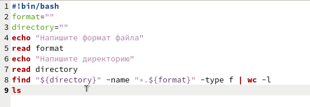

Написанная программа 4

## Выполнение программы 4

И далее, я могу его запустить bash

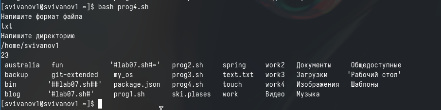

Выполнение программы 4

# Вывод

## Вывод

При выполнении данной лабораторной работы я изучил основы программирования в оболочке ОС UNIX/Linux, научился писать небольшие командные файлы.

## Список литературы

https://esystem.rudn.ru/mod/page/view.php?id=1098933